# Poke-Stats Analysis Summer2026

```python
import pandas as pd
import seaborn as sns
input_csv = (r'C:\Users\lucas\Downloads\Code\Summer 2026\Pokemon Visualizer\pokemon_full.csv')
df = pd.read_csv(input_csv)
print(df)
```

```
      Unnamed: 0  pokedex_number                     name  type_1  type_2  \
0              0               1                Bulbasaur   Grass  Poison
1              1               2                  Ivysaur   Grass  Poison
2              2               3                 Venusaur   Grass  Poison
3              3               4               Charmander    Fire     NaN
4              4               5               Charmeleon    Fire     NaN
...          ...             ...                      ...     ...     ...
1345        1345           10321            Glimmora-Mega    Rock  Poison
1346        1346           10322     Tatsugiri-Curly-Mega  Dragon   Water
1347        1347           10323    Tatsugiri-Droopy-Mega  Dragon   Water
1348        1348           10324  Tatsugiri-Stretchy-Mega  Dragon   Water
1349        1349           10325          Baxcalibur-Mega  Dragon     Ice

       hp  attack  defense  sp_attack  sp_defense  ...               genus  \
0      45      49       49         65          65  ...        Seed Pokémon
```

[output cut: 51 more lines]

```python
import pandas as pd
input_csv = (r'C:\Users\lucas\Downloads\Code\Summer 2026\Pokemon Visualizer\pokemon_normalized.csv')
df = pd.read_csv(input_csv)
print(df)
```

```
      pokedex_number                     name  type_1  type_2   hp  attack  \
0                  1                Bulbasaur   Grass  Poison   45      49
1                  2                  Ivysaur   Grass  Poison   60      62
2                  3                 Venusaur   Grass  Poison   80      82
3                  4               Charmander    Fire     NaN   39      52
4                  5               Charmeleon    Fire     NaN   58      64
...              ...                      ...     ...     ...  ...     ...
1345           10321            Glimmora-Mega    Rock  Poison   83      90
1346           10322     Tatsugiri-Curly-Mega  Dragon   Water   68      65
1347           10323    Tatsugiri-Droopy-Mega  Dragon   Water   68      65
1348           10324  Tatsugiri-Stretchy-Mega  Dragon   Water   68      65
1349           10325          Baxcalibur-Mega  Dragon     Ice  115     175

      defense  sp_attack  sp_defense  speed  ...               genus  \
0          49         65          65     45  ...        Seed Pokémon
```

[output cut: 51 more lines]

```python
norm_stats = []

hp_cluster = df.groupby('type_1')['hp_norm'].mean()
atk_cluster = df.groupby('type_1')['atk_norm'].mean()
def_cluster = df.groupby('type_1')['def_norm'].mean()
spatk_cluster = df.groupby('type_1')['sp_atk_norm'].mean()
spdef_cluster = df.groupby('type_1')['sp_def_norm'].mean()
speed_cluster = df.groupby('type_1')['speed_norm'].mean()

cluster_df = pd.concat([hp_cluster, atk_cluster, def_cluster, spatk_cluster, spdef_cluster, speed_cluster], axis=1)
print(cluster_df)
```

```
           hp_norm  atk_norm  def_norm  sp_atk_norm  sp_def_norm  speed_norm
type_1
Bug       0.223208  0.365576  0.281375     0.235156     0.204760    0.297490
Dark      0.286214  0.453797  0.279430     0.309370     0.233678    0.379406
Dragon    0.337382  0.531012  0.322380     0.417969     0.292631    0.422599
Electric  0.238465  0.373459  0.240000     0.371456     0.216435    0.440205
Fairy     0.282227  0.357992  0.283382     0.360194     0.311801    0.327033
Fighting  0.305436  0.569922  0.314615     0.242640     0.229523    0.396774
Fire      0.279996  0.438867  0.268270     0.384073     0.235870    0.362149
Flying    0.282859  0.420374  0.258713     0.305825     0.242140    0.410256
Ghost     0.243943  0.367360  0.299686     0.355302     0.265217    0.315878
Grass     0.265522  0.406469  0.282436     0.327073     0.229009    0.295250
Ground    0.290866  0.497622  0.339592     0.230388     0.205652    0.305436
Ice       0.291607  0.405651  0.286364     0.294572     0.226482    0.327156
Normal    0.307483  0.389034  0.233182     0.242823     0.198342    0.333850
Poison    0.293383  0.390541  0.295212     0.294903     0.239799    0.322682
Psychic   0.286058  0.379396  0.274718     0.437407     0.291611    0.385098
Rock      0.262499  0.457245  0.369806     0.270733     0.237716    0.300031
Steel     0.286417  0.494387  0.444584     0.340926     0.263712    0.280473
Water     0.282333  0.398176  0.281684     0.322087     0.225516    0.332147
```

```python
pip install seaborn
```

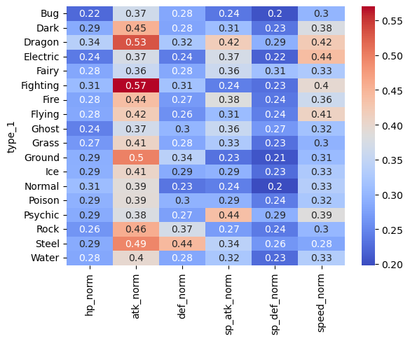

```python
sns.heatmap(cluster_df, annot=True, cmap='coolwarm')
```

## Stat Clustering. I expected that the statistics of Pokémon types would line up logically with common sense in the real world: electric is the fastest, steel is slow, fire has more attack, etc. We can see that electric and dragon types are the quickest, psychic has the highest special attack, and steel has the highest defense, but ALSO is the slowest. Fighting and Dragon have the highest physical attack, along with Ground and Steel; this makes sense for very bulky and physical Pokémon. While types such as water, ghost, grass, and fairy are more all-rounded. Utilizing common sense, we can assume the statistics of Pokémon types are based on real-world assumptions and stereotypes assigned to the elements. This is just using the statistics; we can also factor in the number of Pokémon for each type later.